# Analysis Data Reviewer’s Guide

R Consortium R Submission Pilot 4

Author

R Consortium

# Introduction

## Purpose

The Analysis Data Reviewer’s Guide (ADRG) provides specific instructions for executing a Shiny application created with the R-language for viewing analysis results and performing custom subpopulation analysis based on the data sets and analytical methods used in the [R Consortium R Submission Pilot 1](https://github.com/RConsortium/submissions-pilot1-to-fda). This document provides context for the analysis datasets and terminology that benefit from additional explanation beyond the Data Definition document (define.xml), as well as a summary of ADaM conformance findings. Section 9 provides detailed procedures for installing and configuring a local R environment to view the included Shiny application.

## Study Data Standards and Dictionary Inventory

| Standard or Dictionary | Versions Used |
| --- | --- |
| SDTM | SDTM v1.4/ SDTM IG v3.1.2 |
| ADaM | ADaM v2.1/ ADaM IG v1.0 |
| Controlled Terminology | SDTM CT 2011-12-09 ADaM CT 2011-07-22 |
| Data Definitions | define.xml v2.0 |
| Medications Dictionary | MedDRA v8.0 |

## Source Data Used for Analysis Dataset Creation

The ADaMs we used to regenerate the outputs were the PHUSE CDISC Pilot replication ADaMs following ADaM IG v1.0. The ADaM dataset and its corresponding SDTM data set are publicly available at the PHUSE Github Repository (https://github.com/phuse-org/phuse-scripts/blob/master/data/adam/TDF_ADaM_v1.0.zip, https://github.com/phuse-org/phuse-scripts/blob/master/data/sdtm/TDF_SDTM_v1.0%20.zip)

# Protocol Description

## Protocol Number and Title

Protocol Number: CDISCPilot1

Protocol Title: Safety and Efficacy of the Xanomeline Transdermal Therapeutic System (TTS) in Patients with Mild to Moderate Alzheimer’s Disease

The reference documents can be found at https://github.com/phuse-org/phuse-scripts/blob/master/data/adam/TDF_ADaM_v1.0.zip

## Protocol Design in Relation to ADaM Concepts

Objectives:

The objectives of the study were to evaluate the efficacy and safety of transdermal xanomeline, 50cm and 75cm, and placebo in subjects with mild to moderate Alzheimer’s disease.

Methodology:

This was a prospective, randomized, multi-center, double-blind, placebo-controlled, parallel-group study. Subjects were randomized equally to placebo, xanomeline low dose, or xanomeline high dose. Subjects applied 2 patches daily and were followed for a total of 26 weeks.

Number of Subjects Planned:

300 subjects total (100 subjects in each of 3 groups)

Study schema:

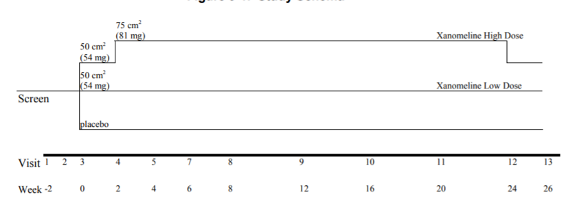

# Analysis Considerations Related to Multiple Analysis Datasets

## Core Variables

Core variables are those that are represented across all/most analysis datasets.

| Variable Name | Variable Description |
| --- | --- |
| USUBJID | Unique subject identifier |
| STUDYID | Study Identifier |
| SITEID | Study Site Identifier |
| TRTSDT | Date of First Exposure to Treatment |
| TRTEDT | Date of Last Exposure to Treatment |
| AGE | Age |
| AGEGR1 | Pooled Age Group 1 |
| AGEGR1N | Pooled Age Group 1 (N) |
| SEX | Sex |
| RACE | Race |
| RACEN | Race (N) |

## Treatment Variables

- Are the values of `ARM` equivalent in meaning to values of `TRTxxP`? Yes
- Are the values of `TRTxxA` equivalent in meaning to values of `TRTxxP`? Yes
- Are both planned and actual treatment variables used in analyses? Yes

## Use of Visit Windowing, Unscheduled Visits, and Record Selection

- Was windowing used in one or more analysis datasets? Yes
- Were unscheduled visits used in any analyses? Yes

## Imputation/Derivation Methods

Not applicable

# Analysis Data Creation and Processing Issues

## Data Dependencies

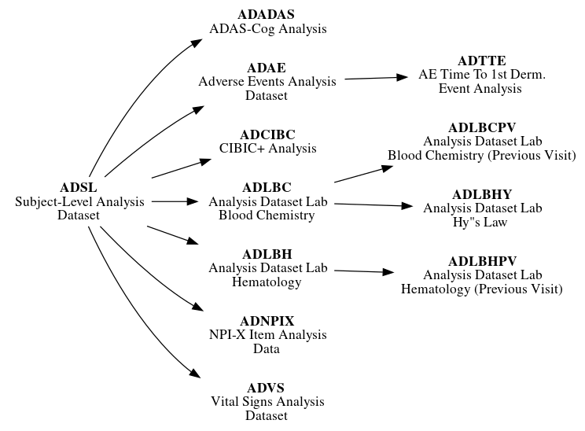

# Analysis Dataset Description

## Overview

The analysis codes and outputs submitted in Pilot 1 and the Shiny application modules in Pilot 2 cover part of the efficacy and safety objectives of the initial protocol. More specifically, 5 analysis outputs are included, covering demographics analysis, primary efficacy endpoint analysis, safety analysis, and visit completion.

## Analysis Datasets

The following table provides detailed information for each analysis dataset included in the Pilot 1 submission. The Shiny application for this pilot utilizes the following analysis datasets: `ADSL`, `ADTTE`, `ADADAS`, `ADLBC`.

| Dataset | Label | Class | Efficacy | Safety | Baseline or other subject characteristics | Primary Objective | Structure |
| --- | --- | --- | --- | --- | --- | --- | --- |
| ADSL | Subject Level Analysis Dataset | ADSL |  |  | x |  | One observation per subject |
| ADAE | Adverve Events Analysis Dataset | ADAM OTHER |  | x |  |  | One record per subject per adverse event |
| ADTTE | Time to Event Analysis Dataset | BASIC DATA SCTRUCTURE |  | x |  |  | One observation per subject per analysis parameter |
| ADLBC | Analysis Dataset Lab Blood Chemistry | BASIC DATA SCTRUCTURE |  | x |  |  | One record per subject per parameter per analysis visit |
| ADLBCPV | Analysis Dataset Lab Blood Chemistry (Previous Visit) | BASIC DATA SCTRUCTURE |  | x |  |  | One record per subject per parameter per analysis visit |
| ADLBH | Analysis Dataset Lab Hematology | BASIC DATA SCTRUCTURE |  | x |  |  | One record per subject per parameter per analysis visit |
| ADLBHPV | Analysis Dataset Lab Hematology (Previous Visit) | BASIC DATA SCTRUCTURE |  | x |  |  | One record per subject per parameter per analysis visit |
| ADLBHY | Analysis Dataset Lab Hy's Law | BASIC DATA SCTRUCTURE |  | x |  |  | One record per subject per parameter per analysis visit |
| ADADAS | ADAS-Cog Analysis | BASIC DATA SCTRUCTURE | x |  |  | x | One record per subject per parameter per analysis visit per analysis date |
| ADCIBC | CIBIC+ Analysis | BASIC DATA SCTRUCTURE | x |  |  |  | One record per subject per parameter per analysis visit per analysis date |
| ADNPIX | NPI-X Item Analysis Data | BASIC DATA SCTRUCTURE | x |  |  |  | One record per subject per parameter per analysis visit |
| ADVS | Vital Signs Analysis Dataset | BASIC DATA SCTRUCTURE |  | x |  |  | One record per subject per parameter per analysis visit |

### ADSL - Subject Level Analysis Dataset

The subject level analysis dataset (ADSL) contains required variables for demographics, treatment groups, and population flags. In addition, it contains other baseline characteristics that were used in both safety and efficacy analyses. All patients in DM were included in ADSL.

The following are the key population flags are used in analyses for patients:

• SAFFL – Safety Population Flag (all patients having received any study treatment)

• ITTFL – Intent-to-Treat Population Flag (all randomized patients)

### ADAE - Adverse Events Analysis Data

ADAE contains one record per reported event per subject. Subjects who did not report any Adverse Events are not represented in this dataset. The data reference for ADAE is the SDTM

Events of particular interest (dermatologic) are captured in the customized query variable (CQ01NAM) in this dataset. Since ADAE is a source for ADTTE, the first chronological occurrence based on the start dates (and sequence numbers) of the treatment emergent dermatological events are flagged (AOCC01FL) to facilitate traceability between these two analysis datasets.

### ADTTE - Time to Event Analysis Dataset

ADTTE contains one observation per parameter per subject. ADTTE is specifically for safety analyses of the time to the first dermatologic adverse event. Dermatologic AEs are considered an adverse event of special interest. The key parameter used for the analysis of time to the first dermatological event is with PARAMCD of “TTDE”.

ADLBC and ADLBH contain one record per lab analysis parameter, per time point, per subject.

ADLBC contains lab chemistry parameters and ADLBH contains hematology parameters and these data are derived from the SDTM LB (Laboratory Tests) domain. Two sets of lab parameters exist in ADLBC/ADLBH. One set contains the standardized lab value from the LB domain and the second set contains change from previous visit relative to normal range values.

In some of the summaries the derived end-of-treatment visit (AVISITN=99) is also presented.

The ADLBC and ADLBH datasets were split based on the values of the indicated variable. Note that this splitting was done to reduce the size of the resulting datasets and to demonstrate split datasets and not because of any guidance or other requirement to split these domains.

### ADLBHY - Laboratory Results Hy’s Law Analysis Data

ADLBHY contains one record per lab test code per sample, per subject for the Hy’s Law based analysis parameters. ADLBHY is derived from the ADLBC (Laboratory Results Chemistry Analysis Data) analysis dataset. It contains derived parameters based on Hy’s law.

### ADADAS - ADAS-COG Data

ADADAS contains analysis data from the ADAS-Cog questionnaire, one of the primary efficacy endpoints. It contains one record per subject per parameter (ADAS-Cog questionnaire item) per VISIT. Visits are placed into analysis visits (represented by AVISIT and AVISITN) based on the date of the visit and the visit windows.

### ADCIBC - CIBC Data

ADCIBC contains analysis data from the from CIBIC+ questionnaire, one of the primary efficacy endpoints. It contains one record per subject per VISIT. Note that for all records, PARAM=‘CIBIC Score’. Visits are placed into analysis visits (represented by AVISIT and AVISITN) based on the date of the visit and the visit windows.

### ADNPIX - NPI-X Item Analysis Data

ADNPIX contains one record per subject per parameter (NPI-X questionnaire item, total score, and mean total score from Week 4 through Week 24) per analysis visit (AVISIT). The analysis visits (represented by AVISIT and AVISITN) are derived from days between assessment date and randomization date and based on the visit windows that were specified in the statistical analysis plan (SAP).

# Data Conformance Summary

## Conformance Inputs

- Were the analysis datasets evaluated for conformance with CDISC ADaM Validation Checks? Yes, Version of CDISO ADaM Validation Checks and software used: Pinnacle 21 Enterprise version 4.1.1
- Were the ADaM datasets evaluated in relation to define.xml? Yes
- Was define.xml evaluated? Yes

## Issues Summary

```r
issue_df_kbl %>%
  kable_styling()
```

| Rule ID | Dataset(s) | Diagnostic Message | Severity | Explanation |
| --- | --- | --- | --- | --- |
| AD0258 | ADAE | Record key from ADaM ADAE is not traceable to SDTM.AE (extra ADAE recs) | Error | There are derived records in ADAE, this has no impact on the analysis. |
| AD0018 | ADLBC, ADLBCPV, ADLBH, ADLBHPV, ADVS, ADCIBC, ADLBNPIX | Variable label mismatch between dataset and ADaM standard | Error | The label for ANL01FL in these datasets are 'Analysis Record Flag 01', this is in conformance with ADaM IG 1.0, this is an issue in P21 checks, and has no impact on the analysis. |
| AD0320 | ADSL | Non-standard dataset label | Error | The label for ADSL is 'ADSL', this has no impact on the analysis |

# Submission of Programs

## Description

The sponsor has provided all programs for analysis results. They are all created on a Linux platform using R version 4.1.2.

## ADaM Programs

Not Applicable. This pilot project only submits programs for analysis results.

## Analysis Output Programs

**Caution**

```r
pilot4_programs_df <- tibble::tibble(
  name = c("app.R", "app_teal.R", "tm_t_demographic.R", "tm_g_kmplot.R", "tm_t_primary.R", "tm_t_efficacy.R", "tm_t_disposition.R"),
  purpose = c("Facilitate execution of Shiny application in a local R session or deployed on a server",
              "Assemble the application modules for use with the Teal package",
              "Shiny module for demographic and baseline characteristics analysis",
              "Shiny module for Kaplan-Meier plot of time to first dermatologic event",
              "Shiny module for primary endpoint analysis ADAS Cog (11)",
              "Shiny module for primary endpoint analysis Glucose (mmol/L)",
              "Shiny module for summary of number of patients completing each visit in treatment period")
)

pilot4_programs_df_kbl <- kbl(
  pilot4_programs_df,
  col.names = c("Program Name", "Purpose")
)

pilot4_programs_df_kbl %>%
  kable_styling(latex_options = c("HOLD_position")) %>%
  column_spec(1, width = "10em") %>%
  column_spec(2, width = "20em")
```

[output not shown]

For reference, below is a description of the analysis programs utilized in Pilot 1.

| Program Name | Output Table Number | Title |
| --- | --- | --- |
| tlf-demographic.r | Table 14-2.01 | Summary of Demographic and Baseline Characteristics |
| tlf-primary.r | Table 14-3.01 | Primary Endpoint Analysis: ADAS Cog (11) - Change from Baseline to Week 24 - LOCF |
| tlf-efficacy.r | Table 14-3.02 | ANCOVA of Change from Baseline at Week 20 |
| tlf-kmplot.r | Figure 14.1 | KM plot for Time to First Dermatologic Event: Safety population |

## Open-source R Analysis Packages

**Caution**

## List of Output Programs

Not Applicable. This pilot project displays analysis output as a Shiny application where the R programs described in the **Analysis Output Programs** as a whole produce the Shiny application.

# Directory Structure

Study datasets and the Shiny application supportive files are organized in accordance to Study Data Technical Conformance Guide.

```
├── m1
│   └── us
│       └── cover-letter.pdf
└── m5
    └── datasets
        └── rconsortiumpilot4
            └── analysis
                └── adam
                    ├── datasets
                    │   ├── adadas.xpt
                    │   ├── adlbc.xpt
                    │   ├── adsl.xpt
                    │   ├── adtte.xpt
                    │   ├── define2-0-0.xsl
                    │   └── define.xml
                    └── programs
                        └── r4app.zip
```

| Directory | Index | Description |
| --- | --- | --- |
| module | 1 | Refers to the eCTD module in which clinical study data is being submitted. |
| datasets | 2 | Resides within the module folder as the top-level folder for clinical study data being submitted for m5. |
| rconsortiumpilot4 | 3 | Study identifier or analysis type performed |
| analysis | 4 | Contains folders for analysis datasets and software programs; arrange in designated level 6 subfolders |
| adam | 5 | Contains subfolders for ADaM datasets and corresponding software programs |
| datasets | 6 | Contains ADaM datasets, analysis data reviewer’s guide, analysis results metadata and define files |
| programs | 7 | Contains Shiny application source files bundled as a zip archive |

# Appendix 1: Pilot 4 Shiny Application Installation and Usage

To install and execute the Shiny application, follow all of the procedures below. Ensure that you note the location of where you downloaded the Pilot 4 eCTD submission files. For demonstration purposes, the procedures below assume the transfer has been saved to this location: `C:\pilot4`.

In addition, create a new directory to hold the unpacked Pilot 4 Shiny application files. For demonstration purposes, the procedures below assume the new directory is this location: `C:\pilot4_files`.

## Installation of R and RStudio

Download and install R 4.2.3 for Windows from https://cran.r-project.org/bin/windows/base/old/4.2.3/R-4.2.3-win.exe. While optional, tt is also recommended to use RStudio IDE for executing R code to launch the application. You can download RStudio for Windows by visiting https://posit.co/download/rstudio-desktop/#download.

When launching RStudio for the first time, you may be prompted to select the version of R to use. Ensure that the default selection of **Use your machine’s default 64-bit version of R** is selected and click OK.

## Installation of Rtools

After the installation is complete, an additional configuration is required in order for R to locate the build tools offered by the Rtools utility. This procedure was adapted from the **Using Rtools on Windows** guide available at https://cran.r-project.org/bin/windows/Rtools/rtools42/rtools.html:

- Launch a new R session, either through the default R GUI or RStudio
- In the R console, run the following command:

```r
write('PATH="${RTOOLS42_HOME}\\usr\\bin;${PATH}"', file = "~/.Renviron", append = TRUE)
```

- Restart your R session by closing and re-opening either the R GUI or RStudio. In the console, run the following command that should give the location of your Rtools installation:

```r
Sys.which("make")
## "C:\\rtools42\\usr\\bin\\make.exe"
```

## Installation of R Packages

```r
install.packages("remotes")

# install version 1.0.3 of the renv package:
remotes::install_version("renv", version = "1.0.3")
```

## Extract Application Bundle

To unpack the Shiny application bundle `r4app.zip`, use the following procedure:

1. Open the folder containing the `r4app.zip` file. Assuming the ECTD transfer has been copied to `C:\pilot4` the archive should be available the following location:

```
C:\pilot4\m5\datasets\rconsortiumpilot4\analysis\adam\programs\r4app.zip
```

2. Right-click the zip file and select **Extract All…** in the context menu.
3. Confirm the destination for the extracted files (it will default to a directory called `r4app` in the same location) and click the **Extract** button.

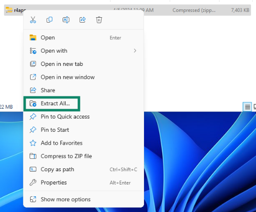

## Initialize R Package Environment

The dependencies for executing the Shiny application are managed by the `renv` R package management system. To bootstrap the customized R package library used for the Shiny application, launch a new R session in the directory where you unpacked the application source files in the previous step. **Choose one of the following options** depending on your R computing environment and preference:

### Option 1: RStudio

Open the RStudio Project file `submissions-pilot4-webR.Rproj` within the directory of the extracted application bundle:

1. Select `File -> Open Project`
2. Click the **Browse** button and navigate to the `r4app` directory to select the `submissions-pilot4-webr.Rproj` file.

RStudio will refresh the window and automatically install the `renv` package into the project directory. You will see a prompt about the installation of the `BiocManager` package. Accept the installation by typing `y` in the console. To complete the process of restoring remaining R packages, run the following command in the R console:

```r
renv::restore(prompt = FALSE)
```

### Option 2: R Console

Launch a new R session in the `r4app` directory of the extracted application bundle. By default, the R Gui interface on Windows will launch a new R session in your default Windows home directory (typically the **Documents** folder). Perform the following steps to ensure R is launched in the proper directory.

**Note**

The procedure below assumes R 4.2.3 has been installed in a default location. If you are unsure of the full path to the R GUI executable on your system, you can find the location on your system by performing the following steps:

1. Open the Windows Start Menu and expand to show all applications.
2. Navigate to the R entry and expand the section such that all R program entries are visible.
3. Right-click the `R x64 4.2.3` entry and select `More -> Open file location`.
4. A new folder window will open with the shortcut `R x64 4.2.3` highlighted. Right-click this entry and select **Properties**
5. In the Properties window, copy the path specified in the **Target** text field. The portion of the text in quotations gives the full path to the `Rgui.exe` location on your system.
1. Open the Windows Powershell program by searching for Windows Powershell in the Windows Start menu.
2. Change the current directory to the `r4app` directory by running the following command (substitute the `r4app` location for your appropriate directory as needed):

```bash
Set-Location -Path "C:\pilot4\m5\datasets\rconsortiumpilot4\analysis\adam\programs\r4app"
```

3. Launch the Windows R GUI in this session by running the following command:

```bash
C:\"Program Files"\R\R-4.2.3\bin\x64\Rgui.exe
```

The R GUI will launch and automatically install the `renv` package into the project directory. You will see a prompt about the installation of the `BiocManager` package. Accept the installation by typing `y` in the console. To complete the process of restoring remaining R packages, run the following command in the R console:

```r
renv::restore(prompt = FALSE)
```

**Note**

Due to certain R packages in the application requiring compilation, the entire package restoration procedure may require at least ten minutes or longer to complete depending on internet bandwidth and your computer’s hardware profile.

Once the package installation process is complete, run the following code to load a set of functions utilized in the remaining steps:

```r
source("utils.R")
```

## Prepare Shiny Application

This pilot contains two options for preparing the Shiny application (choose either option below):

### Option 1: Extract Pre-Compiled Bundle

A pre-compiled version of the application is available inside a compressed zip file archive. Run the following code to extract the archive to a new sub-directory `_site`:

```r
extract_app_bundle()
```

### Option 2: Compile Shiny Application

The second method involves compiling the application in your R environment. Run the following code to compile the Shiny application source files to a new sub-directory `_site`

```r
build_app()
```

**Note**

With the rapid evolution of web-assembly technology in the R ecosystem, this pilot offers two methods of preparing the application as a contingency in the event of any issues.

## Launch Shiny Application

The web-assembly version of the Shiny application can be launched with the following code:

```r
run_app_webassembly()
```

A message appears in the R console displaying the web address of the application. To view the application, launch a new web browser session in Microsoft Edge and paste the address in the address bar. By default, the address will be `localhost:7654`.

**Note**

While not required, the application can also be launched with the traditional method of executing directly in the R session using the following code:

```r
run_app_shiny()
```

# Appendix 2: Application Usage Guide

| Application Tab | Pilot 1 Output |
| --- | --- |
| Demographic Table | Table 14-2.01 Summary of Demographic and Baseline Characteristics |
| KM plot for TTDE | Figure 14-1 Time to Dermatologic Event by Treatment Group |
| Primary Table | Table 14-3.01 Primary Endpoint Analysis: ADAS Cog(11) - Change from Baseline to Week 24 - LOCF |
| Efficacy Table | Table 14-3.02 Primary Endpoint Analysis: Glucose (mmol/L) - Summary at Week 20 - LOCF |
| Visit Completion Table | Not Applicable |

The default display in the analysis tabs match with the outputs submitted in Pilot 1, as well as an additional table on visit completion.

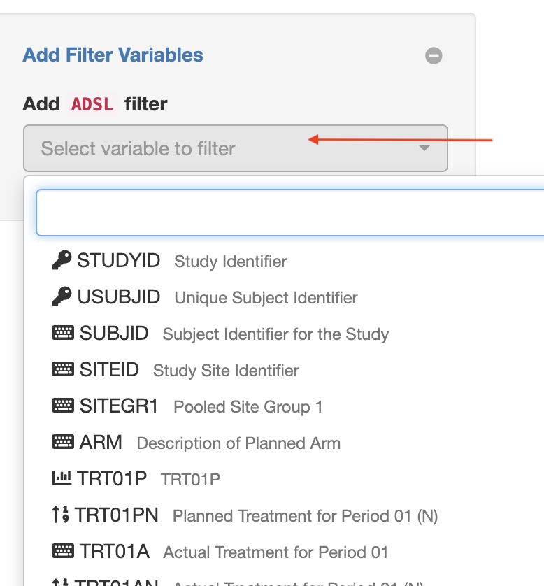

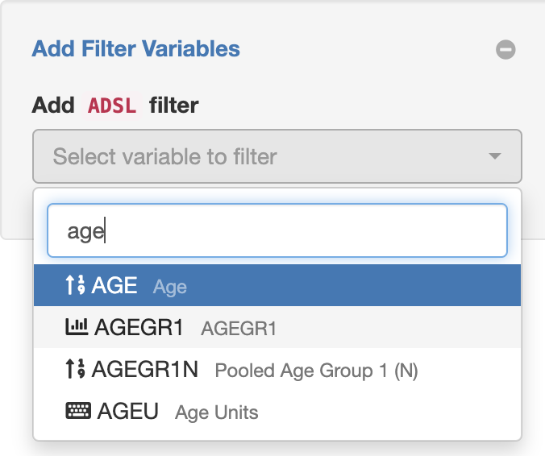

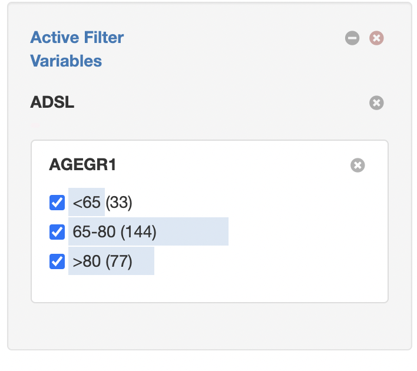

4. Select the target subpopulation (e.g. `>80`) and the analysis output displayed on the left hand side will be updated in real-time according to the selection, which in this example is equivalent to performing a filter on the **ADSL** data by `AGEGR1 == '>80'`.

**Note**

When applying one or more filters in the KM-plot module, the filtered data set may not contain enough observations to produce reliable survival probabilities and associated 95% confidence intervals. In those situations, the application will present to the user a message indicating not enough observations based on the current filter selections.

In addition, the R console could display warnings about value comparisons to a min or max cutoff. These warnings can be safely disregarded as they do not effect the filtered data set after processing is complete.